# Introduction to concstats

Andreas Schneider

Last updated 2026-10-12

The goal of the `concstats` package is to offer a set of alternative and/or additional measures to better determine a given market structure and therefore reduce uncertainty with respect to a given market situation. Various functions or groups of functions are available to achieve the desired goal.

## Installation

You can install `concstats` directly from CRAN or the latest development version from github (requires `remotes` or `devtools`) remotes::install_github(“ropensci/concstats”)

Then, load the package.

```r
library(concstats)
```

## Data

The following examples use mainly fictitious data to present the functions. However, if you want to test the functionality in more detail, the package comes with a small data set of real Paraguayan credit cooperatives (creditcoops). There are 22 paired observations for real Paraguayan credit cooperatives (with assets > 11 Mio. USD) for 2016 and 2018 with their respective total loans granted. For a better visualization there is an additional column with the transformed total loans. For further information on the data please see the `creditcoops` [help](https://docs.ropensci.org/concstats/reference/creditcoops.html) file. For a practical implementation you might be interested to read the following [article](https://doi.org/10.1515/zfgg-2022-0002).

```r
data("creditcoops")
head(creditcoops)
```

```
#> # A tibble: 6 × 5
#>   coop_id year  total_loans paired total_loans_log
#>     <dbl> <fct>       <dbl>  <int>           <dbl>
#> 1       1 2016    173892358      1            19.0
#> 2       1 2018    199048199      1            19.1
#> 3       2 2016    323892456      2            19.6
#> 4       2 2018    461609439      2            20.0
#> 5       3 2016    179981404      3            19.0
#> 6       3 2018    227232008      3            19.2
```

## Group wrapper overview

At the moment, there are the following groups of functions available:  
- `concstats_mstruct()` is a wrapper for market structure measures  
- `concstats_inequ()` is a wrapper for inequality and diversity measures  
- `concstats_comp()` is a wrapper with different concentration measures  
- `concstats_concstats()` is a function which calculates a set of pre-selected measures in a one step procedure to get a quick overview of a given market structure

The functions will be presented in more details in the following short step-by-step guide.

## Examples

We will use a vector which represents market participants with their respective market shares (in decimal form):

### concstats_mstruct

The wrapper includes the following arguments to calculate individual functions: `firm`, `nrs_eq`, `top`, `top3`, `top5`, and `all`. You can also pass the additional argument `digits` to `all`, which controls for the number of digits to be printed.  
All individual functions can be accessed directly with the prefix “concstats_” (e.g. “concstats_firm” or “concstats_all_mstruct”). The concstats_top_df functions also take a data frame as input, since the ranking of firms and their identification might be of interest.

```r
x <- c(0.35, 0.4, 0.05, 0.1, 0.06, 0.04, 0, 0)
test_firm <- concstats_firm(x) # number of firms
test_firm
```

```
#> [1] 6
```

```r
x <- c(0.35, 0.4, 0.05, 0.1, 0.06, 0.04, 0, 0)
test_share_top5 <- concstats_mstruct(x, type = "top5") # top3 market shares in %
test_share_top5
```

```
#> [1] 96
```

Or, just calculate all measures of the group wrapper, and store it in a named object.

```r
x <- c(0.35, 0.4, 0.05, 0.1, 0.06, 0.04, 0, 0)
concstats_all_mstruct(x, na.rm = TRUE, digits = 3)
```

```
#>          Measure Value
#> 1          Firms  6.00
#> 2 Nrs_equivalent  3.33
#> 3        Top (%) 40.00
#> 4       Top3 (%) 85.00
#> 5       Top5 (%) 96.00
```

The result is a data frame of market structure measures.

### concstats_inequ

The inequality and diversity group has the following arguments: `entropy`, `gini`, `simpson`, `palma`, `grs`, and `all`.

They can also be accessed as individual functions.

```r
x <- c(0.35, 0.4, 0.05, 0.1, 0.06, 0.04)
test_share_entropy <- concstats_entropy(x)
test_share_entropy
```

```
#> [1] 0.787806
```

```r
# and as a non-normalized value
test_share_entropy2 <- concstats_entropy(x, normalized = FALSE)
test_share_entropy2
```

```
#> [1] 2.036449
```

### concstats_comp

The group wrapper for competition measures includes the following arguments to calculate `hhi`, `hhi_d`, `hhi_min`, `dom`, `sten`, and `all`.

```r
x <- c(0.35, 0.4, 0.05, 0.1, 0.06, 0.04, 0, 0)
test_share_hhi <- concstats_hhi(x)
test_share_hhi
```

```
#> [1] 0.3002
```

```r
# a normalized value
test_share_hhi2 <- concstats_hhi(x, normalized = TRUE, digits = 3)
test_share_hhi2
```

```
#> [1] 0.16
```

```r
# the min average of the hhi
test_share_hhi3 <- concstats_comp(x, type = "hhi_min")
test_share_hhi3
```

```
#> [1] 0.1666667
```

### concstats_concstats

A single function which calculates a set of eight pre-selected measures in a one step procedure for a first overview of a given market structure. The resulting data frame contains eight measures, which are: number of firms with market share, numbers equivalent, the cumulative share of the top (top 3 and top 5) firm(s) in percentage, the hhi index, the entropy index, and the palma ratio.

```r
x<- c(0.2, 0.3, 0.5)
test_share_conc <- concstats_concstats(x, digit = 2)
test_share_conc
```

```
#>          Measure  Value
#> 1          Firms   3.00
#> 2 Nrs_equivalent   2.63
#> 3        Top (%)  50.00
#> 4       Top3 (%) 100.00
#> 5       Top5 (%) 100.00
#> 6            HHI   0.38
#> 7        Entropy   0.94
#> 8    Palma ratio   2.50
```

## Visualization

The scope of the package is to calculate market structure and concentration measures to get a quick and more informed overview of a given market situation. However, it is good practice to visualize your data in an exploratory step or in reporting your results. The package `concstats` works fine with other Exploratory Data Analysis (EDA) packages or data visualization packages e.g. [`overviewR`](https://CRAN.R-project.org/package=overviewR), [`dataexplorer`](https://CRAN.R-project.org/package=DataExplorer), [`kableExtra`](https://CRAN.R-project.org/package=kableExtra) or [`ggplot2`](https://CRAN.R-project.org/package=ggplot2) to name a few.

Some examples on how you can accomplish this. Let us assume one would like to use the group measure for e.g. market structure, and keep the resulting data frame. We can refine the table using `kableExtra` which works nice with `knitr`.

This time, we will use our `creditcoops` data set again, which comes with the package.

```r
data("creditcoops")
head(creditcoops)
```

```
#> # A tibble: 6 × 5
#>   coop_id year  total_loans paired total_loans_log
#>     <dbl> <fct>       <dbl>  <int>           <dbl>
#> 1       1 2016    173892358      1            19.0
#> 2       1 2018    199048199      1            19.1
#> 3       2 2016    323892456      2            19.6
#> 4       2 2018    461609439      2            20.0
#> 5       3 2016    179981404      3            19.0
#> 6       3 2018    227232008      3            19.2
```

You will need the following two packages. Make sure you have these packages installed.

```r
library(dplyr)
library(kableExtra)
```

Now, we will filter out data for the year 2016.

```r
#data("creditcoops")
coops_2016 <- creditcoops |>  dplyr::filter(year == 2016)
head(coops_2016)

coops_2016 <- coops_2016[["total_loans"]] # atomic vector of total loans
coops_2016 <- coops_2016 / sum(coops_2016)  # market shares in decimal form

# We then use the new object `coops_2016` to calculate the market structure
# measures as a group in a one-step-procedure and capture the results in a
# printed table:
coops_2016_mstruct <- concstats_mstruct(coops_2016, type = "all",
                                        digits = 2)
coops_2016_mstruct_tab <- coops_2016_mstruct |>
  kableExtra::kbl(caption = "Market structure 2016", digits = 2,
                  booktabs = TRUE, align = "r") |>
  kableExtra::kable_classic(full_width = FALSE, html_font = "Arial")
coops_2016_mstruct_tab
```

The result is a nice reusable table.

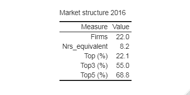

Make sure you have the `ggplot2` package installed. Load the package.

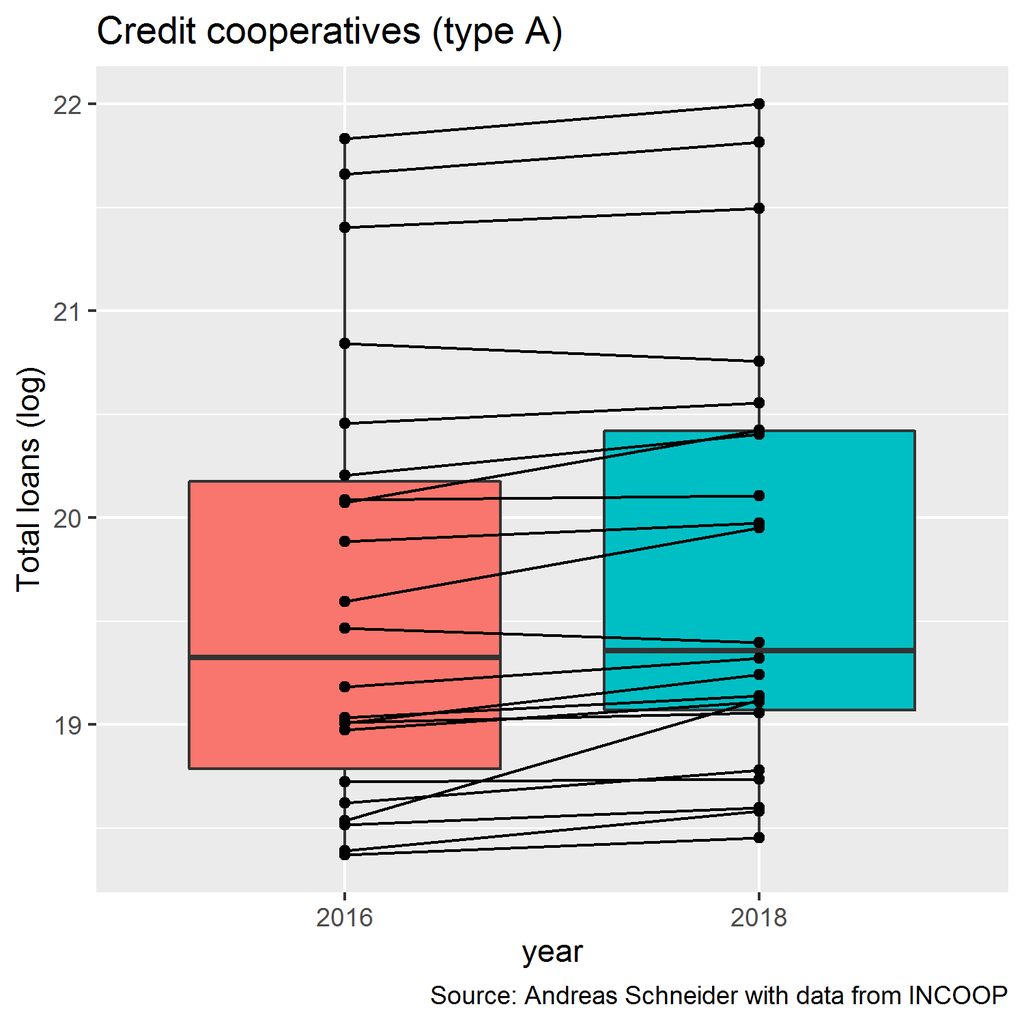

```r
library(ggplot2) # Data Visualizations Using the Grammar of Graphics

df_shares_plot <- df_shares |>
  ggplot(aes(year, total_loans_log, fill = year)) +
  geom_boxplot() +
  geom_point() +
  geom_line(aes(group = paired)) +
  labs(title = "Credit cooperatives (type A)", y = "Total loans (log)",
       caption = "Source: Andreas Schneider with data from INCOOP") +
  theme(legend.position = "none")
df_shares_plot
```

Having a look a the output, we see a box plot with paired values of the cooperatives and the evolution of their respective total loans over time for the two sample years 2016 and 2018.